# Part2_SentimentAnalysis

```r
library(data.table)
library(dplyr)
```

```r
library(ggplot2)
library(stringr)
library(tm)
library(magrittr)
library(textcat)
library(tidytext)
library(RTextTools)
library(RYandexTranslate)
```

Dataset completo con todos los resultados obtenidos del scrapeo por zonas de Madrid: Argüelles, Centro, Chamberí, Chueca, Huertas, Latina, Lavapiés, Plaza Mayor, Prado, Salamanca, Sol.

```r
setwd('/home/usuario/Mis-datos') #Sustituir por el directorio donde se encuentren los datos
filenames <- list.files(full.names=TRUE)
All <- lapply(filenames,function(i){read.csv(i, header=FALSE, skip=4)})
data <- do.call(rbind.data.frame, All)
head(data)
```

```
##                                                                                                                                                                                                                                                                                                          …
## 1                                                                                                                                                                                                                                                                                        Buen restaurante…
## 2                                                                                                                                                                                                                                                                                                        …
## 3 Las pizzas están buenísimas,tienes gran variedad.Desde 9 euros tienes las pizzas artesanas a tu gusto con 3 ingredientes.Estan todas increíbles.El menú infantil hasta 12 años no llega a 7 euros e incluye 1 pizza 1 refresco y 1 postre que pueden ser crepes de nutella que están riquísimos.Ideal p…
## 4                                                                                                                                                                                                      Una de mis pizzas preferidas es la de Aboca. El pizzero es italiano y la calidad es muy alta.  La …
## 5                                                                                                                                                                                                                                                                                                        …
## 6                                                                                                                   Quería agradecer a todo el personal del restaurante, por hacerme sentir como en casa, no solo por la calidad de la comida, se notan que usan ingredientes de buena calidad y producto…
##                           V2                                    V3
## 1 ui_bubble_rating bubble_50                  Buono, bello, giusto
## 2 ui_bubble_rating bubble_40                 RECOMENDABLE PIZZERIA
## 3 ui_bubble_rating bubble_50 Pizzeria artesana con encanto baratas
## 4 ui_bubble_rating bubble_50                         Gran Pizzeria
## 5 ui_bubble_rating bubble_40               Local con mucho encanto
## 6 ui_bubble_rating bubble_50                   En sitio encantador
##              V4 V5             V6  V7
## 1 28027 Madrid,    Aboca Restobar 4,5
## 2 28027 Madrid,    Aboca Restobar 4,5
## 3 28027 Madrid,    Aboca Restobar 4,5
## 4 28027 Madrid,    Aboca Restobar 4,5
## 5 28027 Madrid,    Aboca Restobar 4,5
## 6 28027 Madrid,    Aboca Restobar 4,5
```

Agregar nombre a columnas

```r
colnames(data) <- c("comentario", "puntuacion", "titulo.comentario", "zona", "descripción", "restaurante", "puntuacion.restaurante")
head(data)
```

```
##                                                                                                                                                                                                                                                                                                          …
## 1                                                                                                                                                                                                                                                                                        Buen restaurante…
## 2                                                                                                                                                                                                                                                                                                        …
## 3 Las pizzas están buenísimas,tienes gran variedad.Desde 9 euros tienes las pizzas artesanas a tu gusto con 3 ingredientes.Estan todas increíbles.El menú infantil hasta 12 años no llega a 7 euros e incluye 1 pizza 1 refresco y 1 postre que pueden ser crepes de nutella que están riquísimos.Ideal p…
## 4                                                                                                                                                                                                      Una de mis pizzas preferidas es la de Aboca. El pizzero es italiano y la calidad es muy alta.  La …
## 5                                                                                                                                                                                                                                                                                                        …
## 6                                                                                                                   Quería agradecer a todo el personal del restaurante, por hacerme sentir como en casa, no solo por la calidad de la comida, se notan que usan ingredientes de buena calidad y producto…
##                   puntuacion                     titulo.comentario
## 1 ui_bubble_rating bubble_50                  Buono, bello, giusto
## 2 ui_bubble_rating bubble_40                 RECOMENDABLE PIZZERIA
## 3 ui_bubble_rating bubble_50 Pizzeria artesana con encanto baratas
## 4 ui_bubble_rating bubble_50                         Gran Pizzeria
## 5 ui_bubble_rating bubble_40               Local con mucho encanto
## 6 ui_bubble_rating bubble_50                   En sitio encantador
##            zona descripción    restaurante puntuacion.restaurante
## 1 28027 Madrid,             Aboca Restobar                    4,5
## 2 28027 Madrid,             Aboca Restobar                    4,5
## 3 28027 Madrid,             Aboca Restobar                    4,5
## 4 28027 Madrid,             Aboca Restobar                    4,5
## 5 28027 Madrid,             Aboca Restobar                    4,5
## 6 28027 Madrid,             Aboca Restobar                    4,5
```

Unificar columnas y eliminar las que no son necesarias para el posterior análisis

```r
data$comentario <- str_replace(data$comentario, "Mostrar menos", "")
head(data)
```

```
##                                                                                                                                                                                                                                                                                                          …
## 1                                                                                                                                                                                                                                                                           Buen restaurante, con un loca…
## 2                                                                                                                                                                                                                                                                                                        …
## 3 Las pizzas están buenísimas,tienes gran variedad.Desde 9 euros tienes las pizzas artesanas a tu gusto con 3 ingredientes.Estan todas increíbles.El menú infantil hasta 12 años no llega a 7 euros e incluye 1 pizza 1 refresco y 1 postre que pueden ser crepes de nutella que están riquísimos.Ideal p…
## 4                                                                                                                                                                                                      Una de mis pizzas preferidas es la de Aboca. El pizzero es italiano y la calidad es muy alta.  La …
## 5                                                                                                                                                                                                                                                                                                        …
## 6                                                                                                                   Quería agradecer a todo el personal del restaurante, por hacerme sentir como en casa, no solo por la calidad de la comida, se notan que usan ingredientes de buena calidad y producto…
##                   puntuacion                     titulo.comentario
## 1 ui_bubble_rating bubble_50                  Buono, bello, giusto
## 2 ui_bubble_rating bubble_40                 RECOMENDABLE PIZZERIA
## 3 ui_bubble_rating bubble_50 Pizzeria artesana con encanto baratas
## 4 ui_bubble_rating bubble_50                         Gran Pizzeria
## 5 ui_bubble_rating bubble_40               Local con mucho encanto
## 6 ui_bubble_rating bubble_50                   En sitio encantador
##            zona descripción    restaurante puntuacion.restaurante
## 1 28027 Madrid,             Aboca Restobar                    4,5
## 2 28027 Madrid,             Aboca Restobar                    4,5
## 3 28027 Madrid,             Aboca Restobar                    4,5
## 4 28027 Madrid,             Aboca Restobar                    4,5
## 5 28027 Madrid,             Aboca Restobar                    4,5
## 6 28027 Madrid,             Aboca Restobar                    4,5
```

```r
data <- mutate(data, comentario.completo = paste(data$titulo.comentario, "." ,data$comentario))
head(data)
```

```
##                                                                                                                                                                                                                                                                                                          …
## 1                                                                                                                                                                                                                                                                           Buen restaurante, con un loca…
## 2                                                                                                                                                                                                                                                                                                        …
## 3 Las pizzas están buenísimas,tienes gran variedad.Desde 9 euros tienes las pizzas artesanas a tu gusto con 3 ingredientes.Estan todas increíbles.El menú infantil hasta 12 años no llega a 7 euros e incluye 1 pizza 1 refresco y 1 postre que pueden ser crepes de nutella que están riquísimos.Ideal p…
## 4                                                                                                                                                                                                      Una de mis pizzas preferidas es la de Aboca. El pizzero es italiano y la calidad es muy alta.  La …
## 5                                                                                                                                                                                                                                                                                                        …
## 6                                                                                                                   Quería agradecer a todo el personal del restaurante, por hacerme sentir como en casa, no solo por la calidad de la comida, se notan que usan ingredientes de buena calidad y producto…
##                   puntuacion                     titulo.comentario
## 1 ui_bubble_rating bubble_50                  Buono, bello, giusto
## 2 ui_bubble_rating bubble_40                 RECOMENDABLE PIZZERIA
## 3 ui_bubble_rating bubble_50 Pizzeria artesana con encanto baratas
## 4 ui_bubble_rating bubble_50                         Gran Pizzeria
## 5 ui_bubble_rating bubble_40               Local con mucho encanto
## 6 ui_bubble_rating bubble_50                   En sitio encantador
##            zona descripción    restaurante puntuacion.restaurante
## 1 28027 Madrid,             Aboca Restobar                    4,5
## 2 28027 Madrid,             Aboca Restobar                    4,5
## 3 28027 Madrid,             Aboca Restobar                    4,5
## 4 28027 Madrid,             Aboca Restobar                    4,5
## 5 28027 Madrid,             Aboca Restobar                    4,5
## 6 28027 Madrid,             Aboca Restobar                    4,5
##                                                                                                                                                                                                                                                                                                          …
## 1                                                                                                                                                                                                                                                                                            Buono, bello…
## 2                                                                                                                                                                                                                                                                                                        …
## 3 Pizzeria artesana con encanto baratas . Las pizzas están buenísimas,tienes gran variedad.Desde 9 euros tienes las pizzas artesanas a tu gusto con 3 ingredientes.Estan todas increíbles.El menú infantil hasta 12 años no llega a 7 euros e incluye 1 pizza 1 refresco y 1 postre que pueden ser crepes…
## 4                                                                                                                                                                                                                              Gran Pizzeria . Una de mis pizzas preferidas es la de Aboca. El pizzero es…
## 5                                                                                                                                                                                                                                                                                                        …
## 6                                                                                                                                     En sitio encantador . Quería agradecer a todo el personal del restaurante, por hacerme sentir como en casa, no solo por la calidad de la comida, se notan que usan …
```

```r
data <- select(data, restaurante, puntuacion, comentario.completo)
head(data)
```

```
##      restaurante                 puntuacion
## 1 Aboca Restobar ui_bubble_rating bubble_50
## 2 Aboca Restobar ui_bubble_rating bubble_40
## 3 Aboca Restobar ui_bubble_rating bubble_50
## 4 Aboca Restobar ui_bubble_rating bubble_50
## 5 Aboca Restobar ui_bubble_rating bubble_40
## 6 Aboca Restobar ui_bubble_rating bubble_50
##                                                                                                                                                                                                                                                                                                          …
## 1                                                                                                                                                                                                                                                                                            Buono, bello…
## 2                                                                                                                                                                                                                                                                                                        …
## 3 Pizzeria artesana con encanto baratas . Las pizzas están buenísimas,tienes gran variedad.Desde 9 euros tienes las pizzas artesanas a tu gusto con 3 ingredientes.Estan todas increíbles.El menú infantil hasta 12 años no llega a 7 euros e incluye 1 pizza 1 refresco y 1 postre que pueden ser crepes…
## 4                                                                                                                                                                                                                              Gran Pizzeria . Una de mis pizzas preferidas es la de Aboca. El pizzero es…
## 5                                                                                                                                                                                                                                                                                                        …
## 6                                                                                                                                     En sitio encantador . Quería agradecer a todo el personal del restaurante, por hacerme sentir como en casa, no solo por la calidad de la comida, se notan que usan …
```

Nos quedamos con las filas que tienen puntuación y con las que tienen comentarios de una longitud mayor que 5.

```r
data <- data.table(data)
```

```r
data$puntuacion <- as.character(data$puntuacion)
```

```r
data <- data[puntuacion %in% c('ui_bubble_rating bubble_50',
                                       'ui_bubble_rating bubble_40',
                                       'ui_bubble_rating bubble_30',
                                       'ui_bubble_rating bubble_20',
                                       'ui_bubble_rating bubble_10')]
data <- data[length(data$comentario.completo) >= 5]
```

```r
data$puntuacion[data$puntuacion == 'ui_bubble_rating bubble_10'] <- 1
data$puntuacion[data$puntuacion == 'ui_bubble_rating bubble_20'] <- 2
data$puntuacion[data$puntuacion == 'ui_bubble_rating bubble_30'] <- 3
data$puntuacion[data$puntuacion == 'ui_bubble_rating bubble_40'] <- 4
data$puntuacion[data$puntuacion == 'ui_bubble_rating bubble_50'] <- 5
data$puntuacion <- as.integer(data$puntuacion)
```

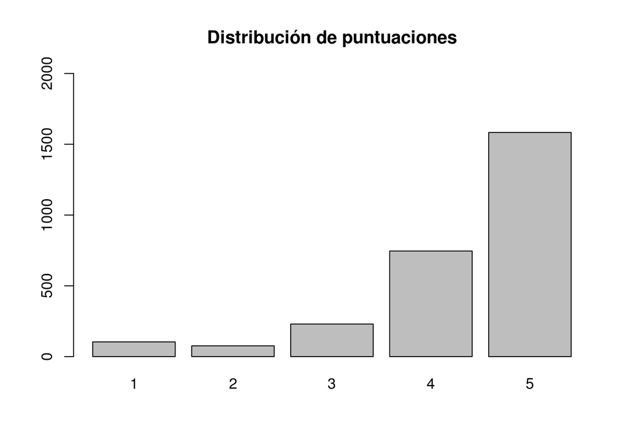

```r
barplot(table(as.factor(data$puntuacion)),
        ylim = c(0,2000),
        main = "Distribución de puntuaciones")
```

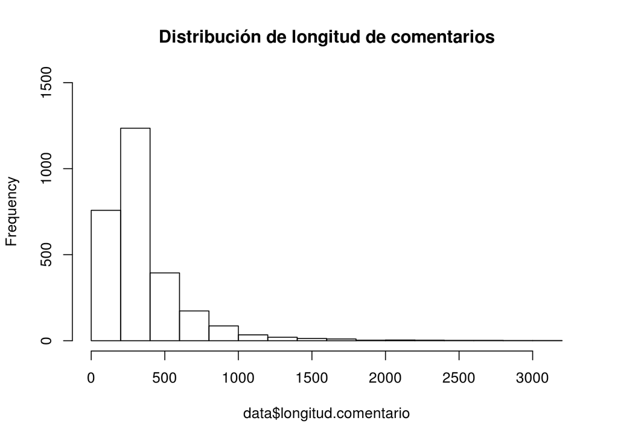

```r
data$longitud.comentario = nchar(data$comentario.completo)
hist(data$longitud.comentario,
     ylim = c(0,1500),
     main = "Distribución de longitud de comentarios" )
```

En cuanto a la longitud de los comentarios, podemos comprobar que hay 13 con una longitud superior a 2000, que procederemos a eliminar para evitar que pueda alterase el peso de una palabra muy repetida dentro de un mismo comentario.

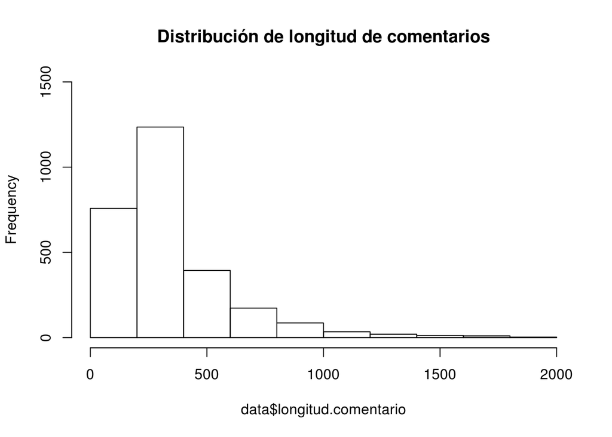

```r
n <- nrow(data[data$longitud.comentario >= 2000])
data <- data[data$longitud.comentario <= 2000]
hist(data$longitud.comentario,
     ylim = c(0,1500),
     main = "Distribución de longitud de comentarios" )
```

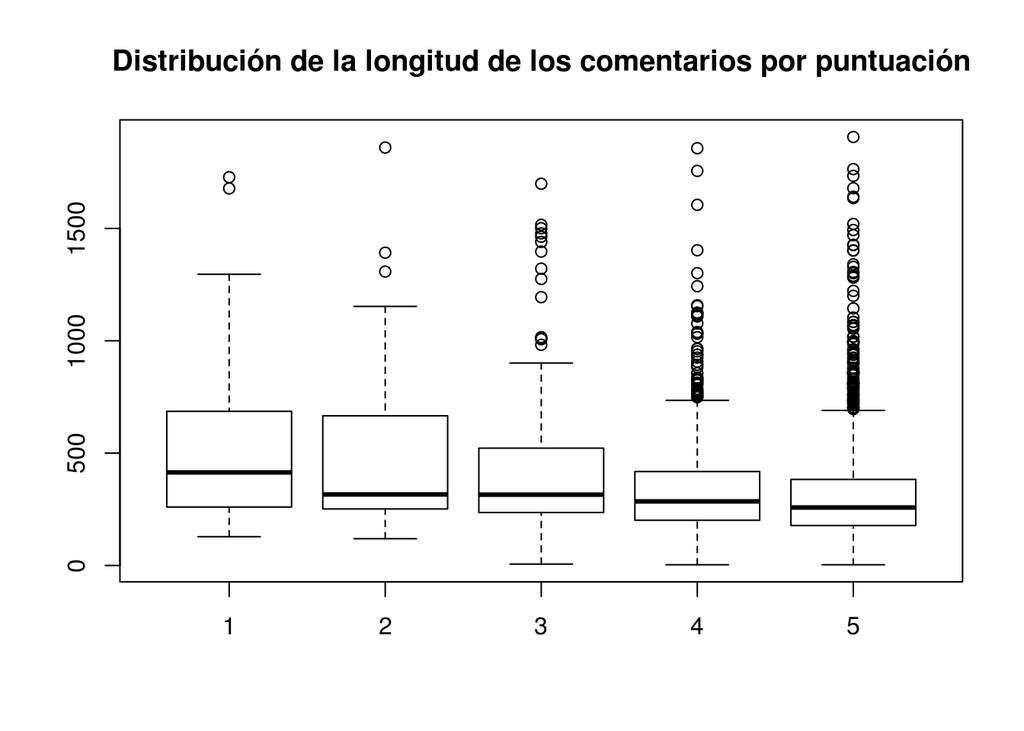

```r
with(data, boxplot(longitud.comentario~puntuacion,
                   main = "Distribución de la longitud de los comentarios por puntuación"))
```

```r
data$review.id <- 1:nrow(data)
```

Traducción de comentarios

```r
api_key="trnsl.1.1.20180621T171618Z.cabc0e463fa891cb.e0f7bcfefcae260b953dfc06f64a447345c7d5f2"
directions=get_translation_direction(api_key)
head(directions)
```

```
## $dirs
##   [1] "az-ru" "be-bg" "be-cs" "be-de" "be-en" "be-es" "be-fr" "be-it"
##   [9] "be-pl" "be-ro" "be-ru" "be-sr" "be-tr" "bg-be" "bg-ru" "bg-uk"
##  [17] "ca-en" "ca-ru" "cs-be" "cs-en" "cs-ru" "cs-uk" "da-en" "da-ru"
##  [25] "de-be" "de-en" "de-es" "de-fr" "de-it" "de-ru" "de-tr" "de-uk"
##  [33] "el-en" "el-ru" "en-be" "en-ca" "en-cs" "en-da" "en-de" "en-el"
##  [41] "en-es" "en-et" "en-fi" "en-fr" "en-hu" "en-it" "en-lt" "en-lv"
##  [49] "en-mk" "en-nl" "en-no" "en-pt" "en-ru" "en-sk" "en-sl" "en-sq"
##  [57] "en-sv" "en-tr" "en-uk" "es-be" "es-de" "es-en" "es-ru" "es-uk"
##  [65] "et-en" "et-ru" "fi-en" "fi-ru" "fr-be" "fr-de" "fr-en" "fr-ru"
##  [73] "fr-uk" "hr-ru" "hu-en" "hu-ru" "hy-ru" "it-be" "it-de" "it-en"
##  [81] "it-ru" "it-uk" "lt-en" "lt-ru" "lv-en" "lv-ru" "mk-en" "mk-ru"
##  [89] "nl-en" "nl-ru" "no-en" "no-ru" "pl-be" "pl-ru" "pl-uk" "pt-en"
##  [97] "pt-ru" "ro-be" "ro-ru" "ro-uk" "ru-az" "ru-be" "ru-bg" "ru-ca"
## [105] "ru-cs" "ru-da" "ru-de" "ru-el" "ru-en" "ru-es" "ru-et" "ru-fi"
## [113] "ru-fr" "ru-hr" "ru-hu" "ru-hy" "ru-it" "ru-lt" "ru-lv" "ru-mk"
## [121] "ru-nl" "ru-no" "ru-pl" "ru-pt" "ru-ro" "ru-sk" "ru-sl" "ru-sq"
## [129] "ru-sr" "ru-sv" "ru-tr" "ru-uk" "sk-en" "sk-ru" "sl-en" "sl-ru"
## [137] "sq-en" "sq-ru" "sr-be" "sr-ru" "sr-uk" "sv-en" "sv-ru" "tr-be"
## [145] "tr-de" "tr-en" "tr-ru" "tr-uk" "uk-bg" "uk-cs" "uk-de" "uk-en"
## [153] "uk-es" "uk-fr" "uk-it" "uk-pl" "uk-ro" "uk-ru" "uk-sr" "uk-tr"
```

```r
trans = function (api_key, text = "", lang = "")
{
  url = "https://translate.yandex.net/api/v1.5/tr.json/translate?"
  url = paste(url, "key=", api_key, sep = "")
  if (text != "") {
    url = paste(url, "&text=", text, sep = "")
  }
  if (lang != "") {
    url = paste(url, "&lang=", lang, sep = "")
  }
  url = gsub(pattern = " ", replacement = "%20", x = url)
  d = RCurl::getURL(url, ssl.verifyhost = 0L, ssl.verifypeer = 0L)
  d = jsonlite::fromJSON(d)
  d$code = NULL
  d
}
```

```r
comentario.en <- apply(as.matrix(data[,3]), 1, function(x){trans(api_key,x,lang="es-en")})
```

```r
comentario.estr <- as.data.table(melt(comentario.en))
```

```r
comentario.estr2 <- comentario.estr[comentario.estr$L2 == "text"]
```

```r
data.translate <- data.table(as.matrix(comentario.estr2))
colnames(data.translate) <- c("comentario.en", "text", "review.id")
data.translate$review.id <- as.integer(data.translate$review.id)
```

```r
data.translate <- data %>%
  inner_join(data.translate, by = "review.id") %>%
  select(-c(text, comentario.completo, longitud.comentario))
```

Comprobamos que todo el texto esté en inglés

```r
data.translate <- data.table(data.translate)
data.translate$language <- as.factor(textcat(data.translate$comentario.en))
data.translate <- data.translate[language == "english"]
head(data.translate)
```

```
##       restaurante puntuacion review.id
## 1: Aboca Restobar          5         1
## 2: Aboca Restobar          4         2
## 3: Aboca Restobar          5         3
## 4: Aboca Restobar          5         4
## 5: Aboca Restobar          4         5
## 6: Aboca Restobar          5         6
##                                                                                                                                                                                                                                                                                                          …
## 1:                                                                                                                                                                                                                                                                                                       …
## 2:                                                                                                                                                                                                                                                                                                       …
## 3: Pizzeria artisan with charm cheap . The pizzas are delicious,you have great variety.From 9 euros you can have the pizzas handmade to your taste with 3 ingredients.They are all amazing.The children's menu up to 12 years does not reach € 7 and includes 1 pizza, 1 soda and 1 dessert which can be …
## 4:                                                                                                                                                                                                                                                      Great Pizzeria . One of my pizzas favorite is the…
## 5:                                                                                                                                                                                                                                                                                                       …
## 6:                                                                                                                                                      In a charming site . I wanted to thank all the staff at the restaurant, for making me feel at home, not only for the quality of the food, you not…
##    language
## 1:  english
## 2:  english
## 3:  english
## 4:  english
## 5:  english
## 6:  english
```

Volvemos a eliminar aquellos comentarios que tengan una longitud menor que 5, debido posibles errores en la traducción

```r
data.translate <- data.translate[length(data.translate$comentario.en) >= 5]
```

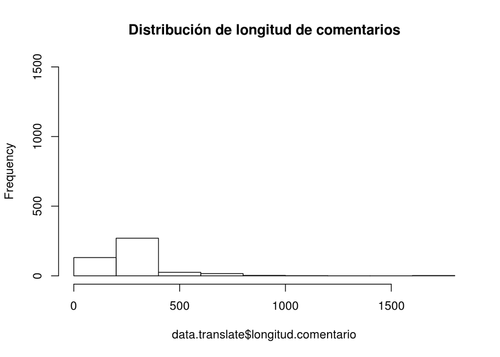

```r
data.translate$longitud.comentario = nchar(data.translate$comentario.en)
hist(data.translate$longitud.comentario,
     ylim = c(0,1500),
     main = "Distribución de longitud de comentarios" )
```

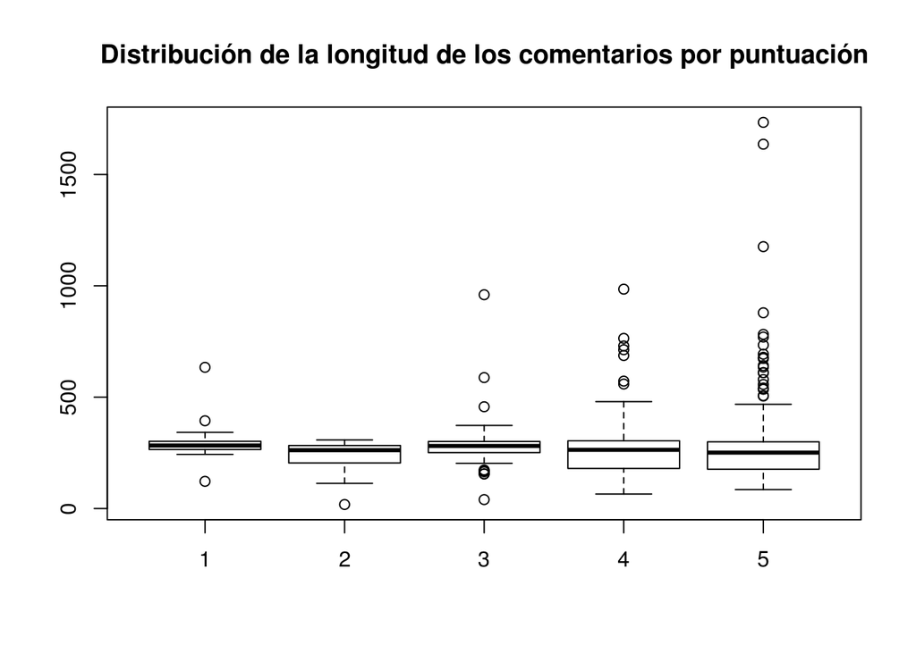

```r
with(data.translate, boxplot(longitud.comentario~puntuacion,
                   main = "Distribución de la longitud de los comentarios por puntuación"))
```

A continuación vamos a utilizar los aspectos positivos o neativos de las palabras para ver si estan correlacionados con la punutacion de los comentarios

```r
# Loading the first sentiment score lexicon
AFINN <- sentiments %>%
  filter(lexicon == "AFINN") %>%
  select(word, afinn_score = score)
head(AFINN)
```

```
## # A tibble: 6 x 2
##   word       afinn_score
##   <chr>            <int>
## 1 abandon             -2
## 2 abandoned           -2
## 3 abandons            -2
## 4 abducted            -2
## 5 abduction           -2
## 6 abductions          -2
```

```r
# Loading the second sentiment score lexicon
Bing <- sentiments %>%
  filter(lexicon == "bing") %>%
  select(word, bing_sentiment = sentiment)
head(Bing)
```

```
## # A tibble: 6 x 2
##   word       bing_sentiment
##   <chr>      <chr>
## 1 2-faced    negative
## 2 2-faces    negative
## 3 a+         positive
## 4 abnormal   negative
## 5 abolish    negative
## 6 abominable negative
```

```r
palabras.comentarios <- data.translate %>%
  unnest_tokens(word, comentario.en) %>%
  select(-c(restaurante, longitud.comentario, language)) %>%
  left_join(AFINN, by = "word") %>%
  left_join(Bing, by = "word")
```

Calculamos la media de sentimiento

```r
media.sentimiento.comentario <- palabras.comentarios %>%
  group_by(review.id, puntuacion) %>%
  summarize(media.sentimiento = mean(afinn_score, na.rm = TRUE))
```

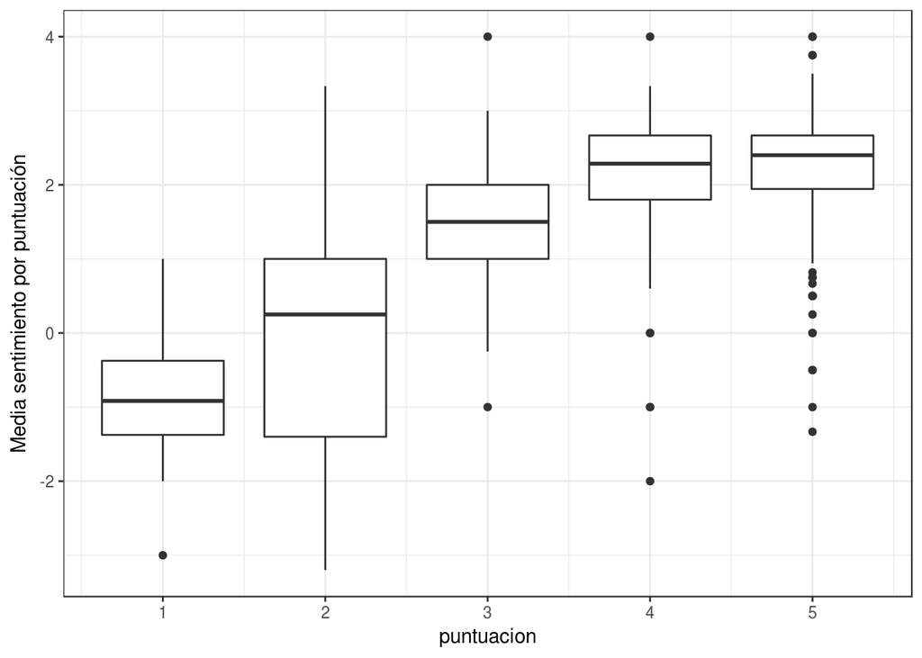

```r
theme_set(theme_bw())
ggplot(media.sentimiento.comentario, aes(puntuacion, media.sentimiento, group = puntuacion)) +
  geom_boxplot() +
  ylab("Media sentimiento por puntuación")
```

```r
media.sentimiento.comentario <- media.sentimiento.comentario %>%
  select(-puntuacion) %>% # Eliminamos las puntuaciones para evitar duplicarlas
  data.table()
clean.data <- data.translate %>%
  left_join(media.sentimiento.comentario, by = "review.id")
```

Mediana

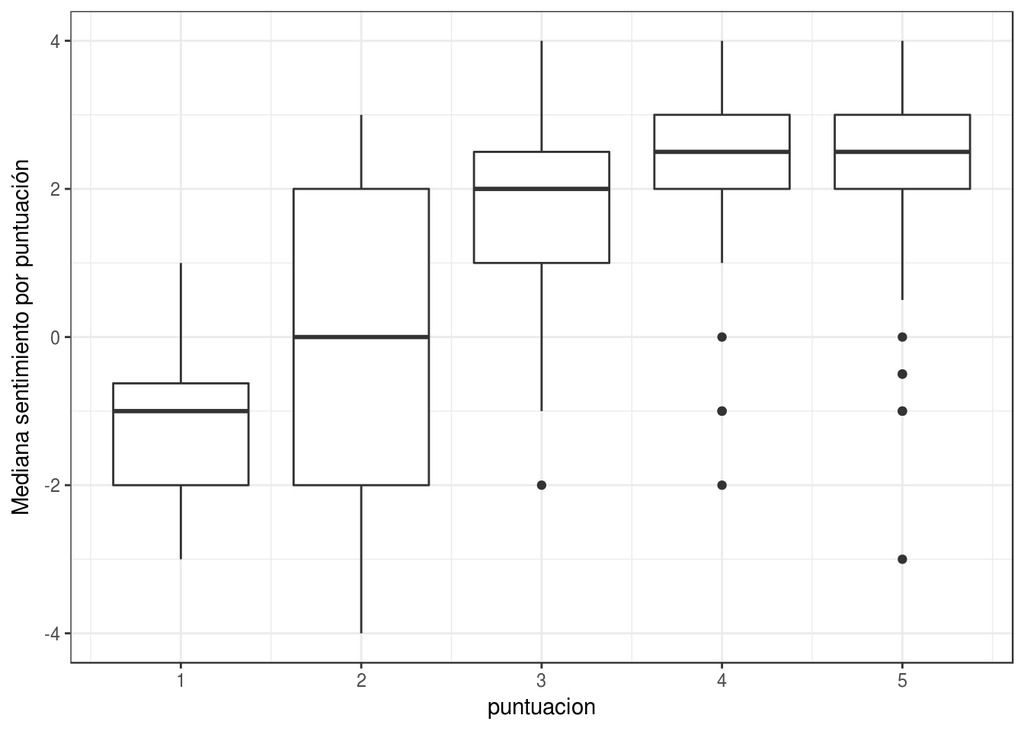

```r
mediana.sentimiento.comentario <- palabras.comentarios %>%
  group_by(review.id, puntuacion) %>%
  summarize(mediana.sentimiento = median(afinn_score, na.rm = TRUE))
theme_set(theme_bw())
ggplot(mediana.sentimiento.comentario, aes(puntuacion, mediana.sentimiento, group = puntuacion)) +
  geom_boxplot() +
  ylab("Mediana sentimiento por puntuación")
```

```r
mediana.sentimiento.comentario <- mediana.sentimiento.comentario %>%
  select(-puntuacion) %>%
  data.table()
clean.data <- clean.data %>%
  left_join(mediana.sentimiento.comentario, by = "review.id")
```

Contar el número de palabras negativas por comentario según AFINN lexicon

```r
comment_count_afinn_negative <- palabras.comentarios %>%
  filter(afinn_score < 0) %>%
  group_by(review.id, puntuacion) %>%
  summarize(count_afinn_negative = n())
# Transferir resultados a nuestro dataset
comment_count_afinn_negative <- comment_count_afinn_negative %>%
  select(-puntuacion) %>%
  data.table()
clean.data <- clean.data %>%
  left_join(comment_count_afinn_negative, by = "review.id")
```

Contar el número de palabras positivas por comentario según AFFIN lexicon

```r
comment_count_afinn_positive <- palabras.comentarios%>%
  filter(afinn_score > 0) %>%
  group_by(review.id, puntuacion) %>%
  summarize(count_afinn_positive = n())
# Transferir resultados a nuestro dataset
comment_count_afinn_positive <- comment_count_afinn_positive %>%
  select(-puntuacion) %>%
  data.table()
clean.data <- clean.data %>%
  left_join(comment_count_afinn_positive, by = "review.id")
```

Contar en número de palabras negativas por comentario según Bing lexicon

```r
comment_count_bing_negative <- palabras.comentarios %>%
  filter(bing_sentiment == "negative") %>%
  group_by(review.id, puntuacion) %>%
  summarize(count_bing_negative = n())
# Transferir resultados a nuestro dataset
comment_count_bing_negative <- comment_count_bing_negative %>%
  select(-puntuacion) %>%
  data.table()
clean.data <- clean.data %>%
  left_join(comment_count_bing_negative, by = "review.id")
```

Contar el númeo de palabras positivas por comentario según Bing lexicon

```r
comment_count_bing_positive <- palabras.comentarios %>%
  filter(bing_sentiment == "positive") %>%
  group_by(review.id, puntuacion) %>%
  summarize(count_bing_positive = n())
# Transferir resultados a nuestro dataset
comment_count_bing_positive <- comment_count_bing_positive %>%
  select(-puntuacion) %>%
  data.table()
clean.data <- clean.data %>%
  left_join(comment_count_bing_positive, by = "review.id")
```

```r
clean.data <- clean.data %>%
  select(-language)
head(clean.data)
```

```
##      restaurante puntuacion review.id
## 1 Aboca Restobar          5         1
## 2 Aboca Restobar          4         2
## 3 Aboca Restobar          5         3
## 4 Aboca Restobar          5         4
## 5 Aboca Restobar          4         5
## 6 Aboca Restobar          5         6
##                                                                                                                                                                                                                                                                                                          …
## 1                                                                                                                                                                                                                                                                                                        …
## 2                                                                                                                                                                                                                                                                                                        …
## 3 Pizzeria artisan with charm cheap . The pizzas are delicious,you have great variety.From 9 euros you can have the pizzas handmade to your taste with 3 ingredients.They are all amazing.The children's menu up to 12 years does not reach € 7 and includes 1 pizza, 1 soda and 1 dessert which can be p…
## 4                                                                                                                                                                                                                                                      Great Pizzeria . One of my pizzas favorite is the …
## 5                                                                                                                                                                                                                                                                                                        …
## 6                                                                                                                                                      In a charming site . I wanted to thank all the staff at the restaurant, for making me feel at home, not only for the quality of the food, you noti…
##   longitud.comentario media.sentimiento mediana.sentimiento
```

[output cut: 20 more lines]

Cargamos los resultados a un csv

```r
write.csv(clean.data, "CleanData.csv", row.names = FALSE)
```